# Bay Wheels Data Exploration

The goal of this analysis is to understand the relationships between distances covered, time spent biking, user type, and periods of the day and any correlations.

## Is there any correlation between distance and time? And, are they influenced by periods of the day and user type?

```python
import matplotlib.pylab as pylab
params = {'legend.fontsize': 'x-large',
          'figure.figsize': (15, 5),
         'axes.labelsize': 'x-large',
         'axes.titlesize':'x-large',
         'xtick.labelsize':'x-large',
         'ytick.labelsize':'x-large'}
pylab.rcParams.update(params)
```

# Data Wrangling Process

Firstly, the data was adjusted and cleaned starting by removing the distances smaller than 50 meters, which is walking distance and larger than 25 km which seems too much for a rented bike. Then, trips over 3 hours long were removed alongside pace extreme values. Three new variables were created during the process.

#### Define

```
- Convert data strings to data type.
- Calculate and add column with the distance in Km.
- Calculate and add column with the pace in Km/h.
- Calculate and add column with the duration in minutes.
```

## Exploratory Analysis

This process is divided into three steps: Univariate Exploration, Bivariate Exploration, and Multivariate Exploration.

## Univariate Exploration

Categorical and Numeric Variables

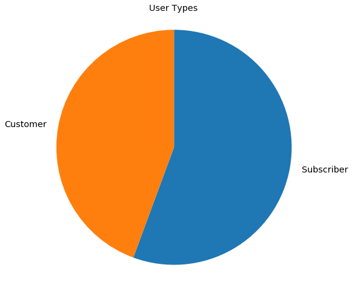

```python
# Piechart user_type

plt.figure(figsize=[8,8])

plt.title('User Types')

def pie_user():
    sorted_counts = df_clean_eda['user_type'].value_counts()
    plt.pie(sorted_counts, labels = sorted_counts.index, startangle = 90, counterclock = False);
    plt.axis('square');

pie_user()
```

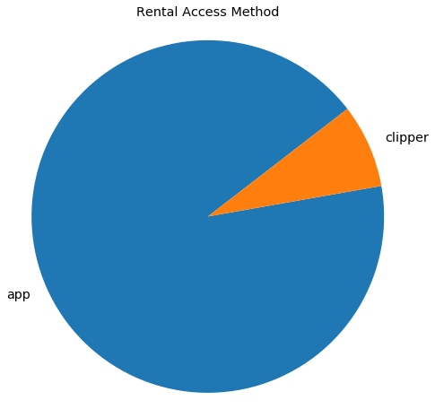

```python
# Piechart rental_access_method

sorted_counts = df_clean_eda['rental_access_method'].value_counts()

plt.figure(figsize=[8,8])

plt.title('Rental Access Method')

def pie_rental():
    plt.pie(sorted_counts, labels = sorted_counts.index, startangle = 10, counterclock = False);
    plt.axis('square');

pie_rental()
```

The proportions in the rental access method, show us that almost 60% of the rentals are via the app, and only 5% via clipper. The rest are not identified and were not removed in this analysis.

### Distances Analysis

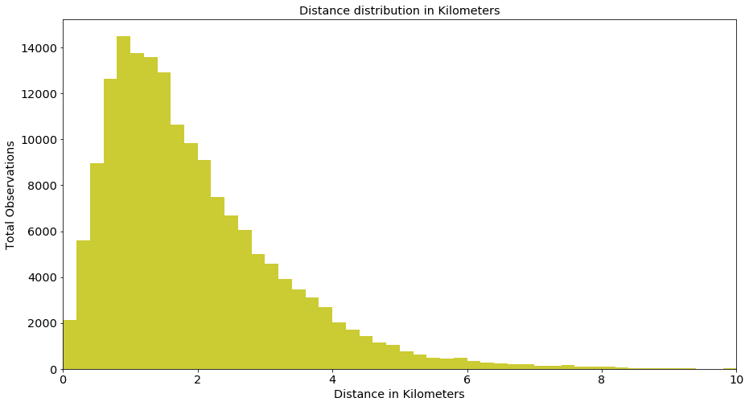

```python
# Verify how the distances are distributed after assessing and cleaning with 10 km limit.

binsize = 0.2
bins = np.arange(0, df_clean_eda['distance_km'].max()+binsize, binsize)

def graph():
    plt.hist(data = df_clean_eda, alpha=0.8, facecolor='y', x = 'distance_km', bins = bins)

plt.figure(figsize=[15,8])
plt.title('Distance distribution in Kilometers')
plt.ylabel('Total Observations')
plt.xlabel('Distance in Kilometers')
plt.xlim([0, 10])

plt.show(graph());
```

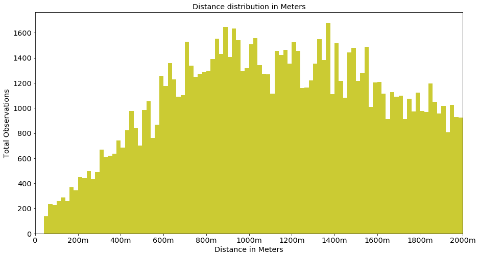

```python
# Verify how the distances are distributed after assessing and cleaning with 2 km limit.

binsize = 0.02
bins = np.arange(0, df_clean_eda['distance_km'].max()+binsize, binsize)

def graph():
    plt.hist(data = df_clean_eda, alpha=0.8, facecolor='y', x = 'distance_km', bins = bins)

plt.figure(figsize=[15,8])
plt.title('Distance distribution in Meters')
plt.ylabel('Total Observations')
plt.xlabel('Distance in Meters')
plt.xticks([0, 0.2, 0.4, 0.6, 0.8, 1, 1.2, 1.4, 1.6, 1.8, 2],['0', '200m', '400m', '600m', '800m', '1000m', '1200m', '1400m', '1600m', '1800m', '2000m'])
plt.xlim([0, 2])

plt.show(graph());
```

### Distance Distribution

The distribution is right-skewed, with almost all the values between 0 and 5m. Let's have a closer look at the values between 0 and 2 kilometers of distance. From the second visualization, we can verify that the most common distance biked by the users is between 800m and 1400m.

### Duration Analysis

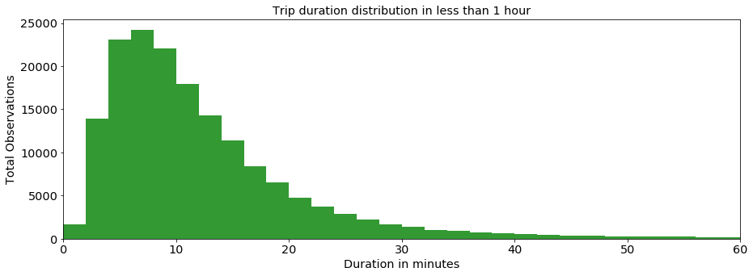

```python
# Verify how the time in minutes is distributed

binsize = 2
bins = np.arange(0, df_clean_eda['duration_min'].max()+binsize, binsize)

def graph():
    plt.hist(data = df_clean_eda, alpha=0.8, facecolor='g', x = 'duration_min', bins = bins)

plt.title('Trip duration distribution in less than 1 hour')
plt.ylabel('Total Observations')
plt.xlabel('Duration in minutes')
plt.xlim([0, 60])

plt.show(graph());
```

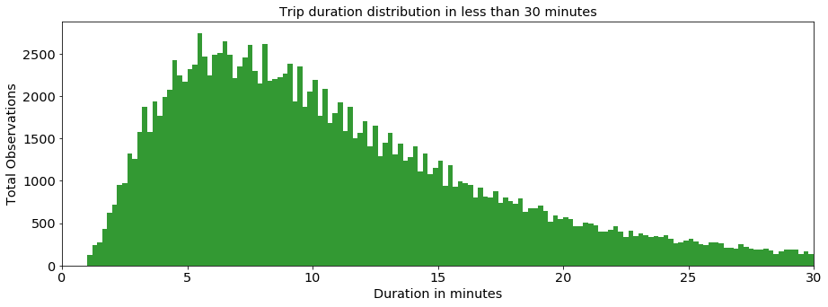

```python
# Verify how the distances are distributed after assessing and cleaning with 2 km limit.

binsize = 0.2
bins = np.arange(0, df_clean_eda['duration_min'].max()+binsize, binsize)

def graph():
    plt.hist(data = df_clean_eda, alpha=0.8, facecolor='g', x = 'duration_min', bins = bins)

plt.title('Trip duration distribution in less than 30 minutes')
plt.ylabel('Total Observations')
plt.xlabel('Duration in minutes')
plt.xlim([0, 30])

plt.show(graph());
```

### Duration Distribution

From the detailed distribution above, it is possible to see that after 10 minutes, the number of observations starts to decrease. People tend to spend between 5 and 10 minutes of biking.

### The Pace Analysis

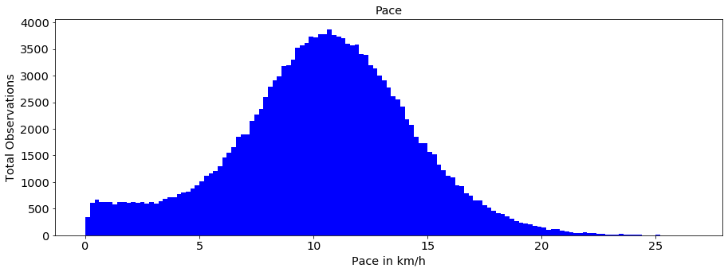

```python
# Verify how the pace is distributed

binsize = 0.2
bins = np.arange(0, df_clean_eda['pace_km_h'].max()+binsize, binsize)

def graph():
    plt.hist(data = df_clean_eda, facecolor='b', x = 'pace_km_h', bins = bins)

plt.title('Pace')
plt.ylabel('Total Observations')
plt.xlabel('Pace in km/h')

plt.show(graph());
```

### The Pace Distribution

The pace is a normal distribution, different from distance and time. From the plot, we can also verify that there are some pace values below 3 km/h which is walking speed. Those might be users that took the bike but for whatever reason walked the bike until the destination station. We can remove those users.

## Bivariate Exploration

### Heat Maps

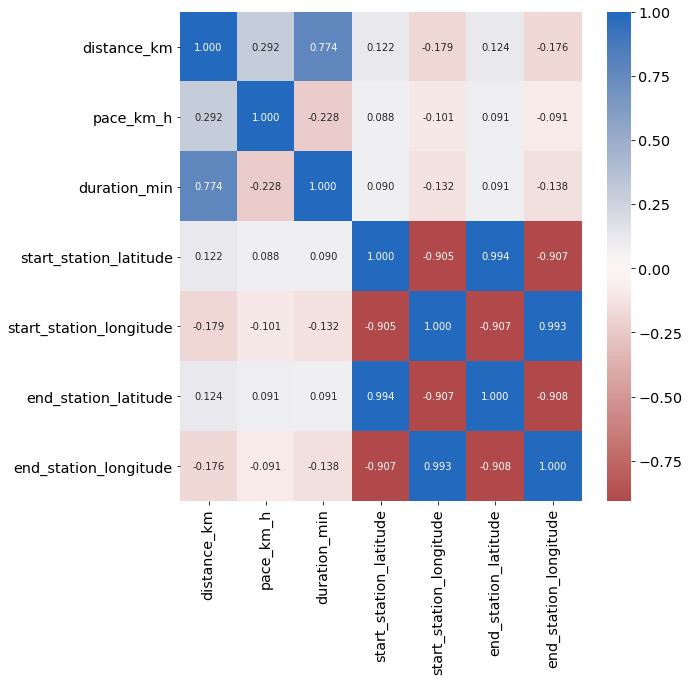

```python
plt.figure(figsize=[9,9])

def graph():
    sb.heatmap(df_clean_eda[numeric_vars].corr(), annot = True, fmt = '.3f', cmap = 'vlag_r', center=0)

graph()
```

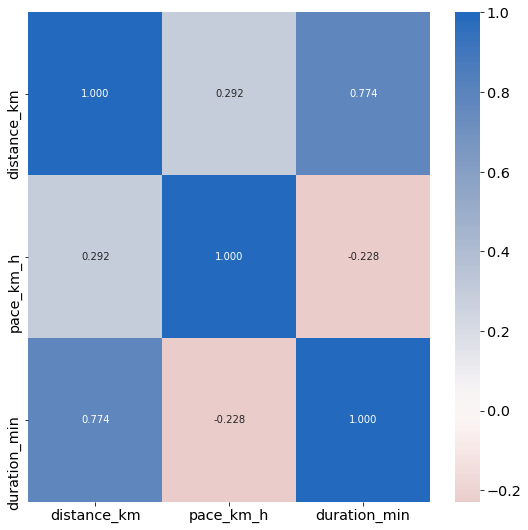

```python
# Correlation plot
plt.figure(figsize=[9,9])

def graph():
    sb.heatmap(df_clean_eda[numeric_vars_short].corr(), annot = True, fmt = '.3f', cmap = 'vlag_r', center=0)

graph()
```

The heatmap between the numeric variables shows us that distance and duration correlate .77. Since it is common sense to use km/h and m/s, we will analyze a scatter plot between time and distance in meters per second.

### Correlation

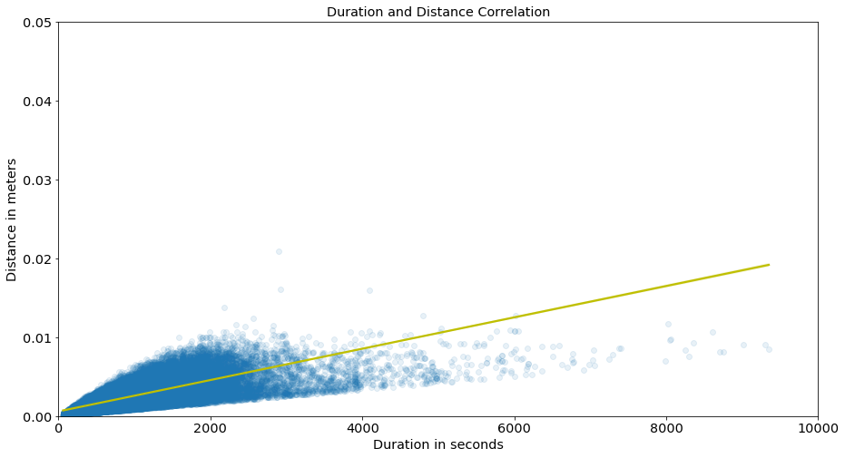

```python
# Scatter plot for duration and distance

ds = df_clean_eda['duration_sec']
dk = df_clean_eda['distance_km']/1000

def graph():
    sb.regplot(ds, dk, color='y', scatter=False);
    sb.regplot(ds, dk, fit_reg=False, scatter_kws = {'alpha':0.1});
    plt.ylabel('Distance in meters')
    plt.xlabel('Duration in seconds')

plt.figure(figsize=[15,8])
plt.grid(False)
plt.title('Duration and Distance Correlation')
plt.ylim([0, 0.05])
plt.xlim([0, 10000])

graph()
```

The positive correlation is now verified in a scatter plot. When the duration of the trip increases, the distance covered tends to increase too.

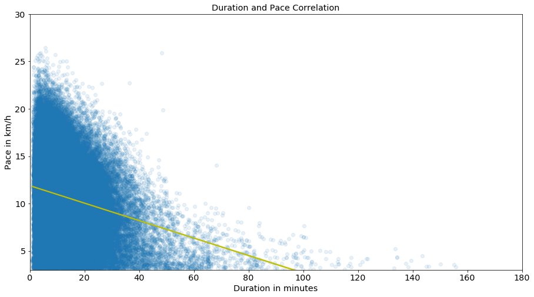

```python
# Scatter plot for pace and duration

pc = df_clean_eda['pace_km_h']
dm = df_clean_eda['duration_min']

def graph():
    sb.regplot(dm, pc, color='y', scatter=False);
    sb.regplot(dm, pc, fit_reg=False, scatter_kws = {'alpha':0.1});
    plt.ylabel('Pace in km/h')
    plt.xlabel('Duration in minutes')

plt.figure(figsize=[15,8])
plt.grid(False)
plt.title('Duration and Pace Correlation')
plt.ylim([3, 30])
plt.xlim([0, 180])

graph()
```

Differently from time and distance correlation, the correlation between pace and time is negative. From the scatter plot above, we can verify the yellow regression line going downwards. This shows a negative correlation, meaning that when the time spent on the bike increases, the pace tends to decrease. It makes a lot of sense! The cyclist eventually gets tired, takes more time no bike and the pacing rate fades.

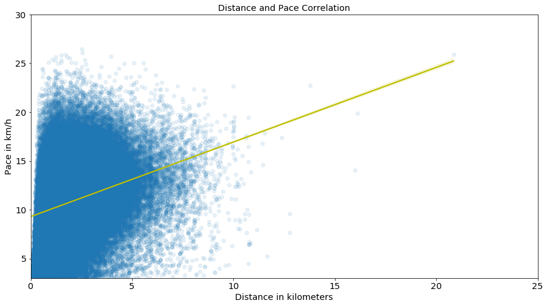

```python
# Scatter plot for pace and distance

pc = df_clean_eda['pace_km_h']
dk = df_clean_eda['distance_km']

def graph():
    sb.regplot(dk, pc, color='y', scatter=False);
    sb.regplot(dk, pc, fit_reg=False, scatter_kws = {'alpha':0.1});
    plt.ylabel('Pace in km/h')
    plt.xlabel('Distance in kilometers')

plt.figure(figsize=[15,8])
plt.grid(False)
plt.title('Distance and Pace Correlation')
plt.ylim([3, 30])
plt.xlim([0, 25])

graph()
```

Now that's interesting, when the duration increases, the pace fades but when the distance increases, the pace also increases. One reasonable explanation is that the body takes some time to head up and reach the peak of performance. The cyclist needs some minimum distance to start performing and reach the peak of performance. From the scatter plot we can also verify the existence of an outlier. That cyclist did more than 20 km with a pace of 25 km/h.

### Violin and Box Visualizations

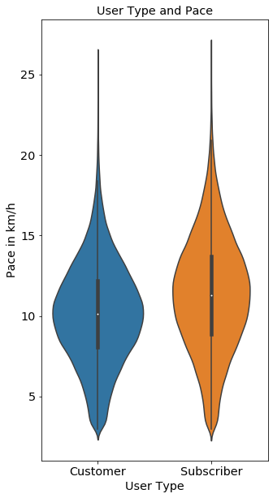

```python
# Violin chart for User Type and Pace

def graph():
    sb.violinplot(data = df_clean_eda, x = 'user_type', y = 'pace_km_h');
    plt.ylabel('Pace in km/h')
    plt.xlabel('User Type')

plt.figure(figsize=[5,10])
plt.title('User Type and Pace')

graph()
```

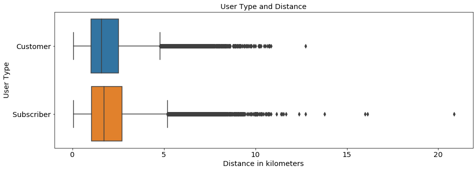

```python
# Box chart for User Type and Distance

def graph():
    sb.boxplot(data = df_clean_eda, x = 'distance_km', y = 'user_type')
    plt.ylabel('User Type')
    plt.xlabel('Distance in kilometers')

plt.figure(figsize=[15,5])
plt.ylim([0, 8])
plt.title('User Type and Distance')

graph()
```

By comparing the user type to the distance covered, we can verify that members (subscribed users) tend to cover longer distances but it is very close compared to customers. The outliers are also close in comparison. The cyclist that covered the larger distance is subscribed.

### Categorical and Numeric Distribution

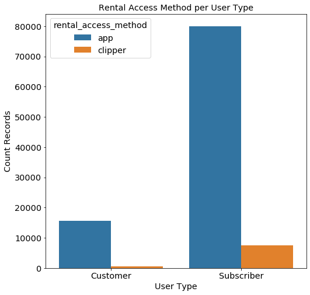

```python
# Clustered Barchart for User Type and Rental Access Method

def graph():
    sb.countplot(data = df_clean_eda, x = 'user_type', hue = 'rental_access_method')
    plt.ylabel('Count Records')
    plt.xlabel('User Type')

plt.figure(figsize=[8,8])

plt.title('Rental Access Method per User Type')

graph()
```

The clustered bar chart above shows us that members are the majority of the APP users. There is a good chance that if you are a member, you'll use the APP to rent a bike. Only a few members use Clipper as the access method.

### Features of Interest X Other Features

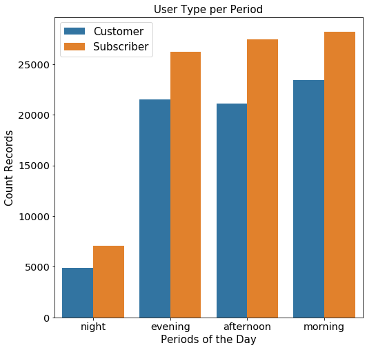

```python
# Clustered Barchart for Period and User Type

def graph():
    sb.countplot(data = df_other, x = 'period', hue = 'user_type')
    plt.ylabel('Count Records', fontsize=15)
    plt.xlabel('Periods of the Day', fontsize=15)
    plt.legend(fontsize=15)

plt.figure(figsize=[8,8])

plt.title('User Type per Period', fontsize=15)

graph()
```

Subscribers are the majority of the users in all periods of the day.

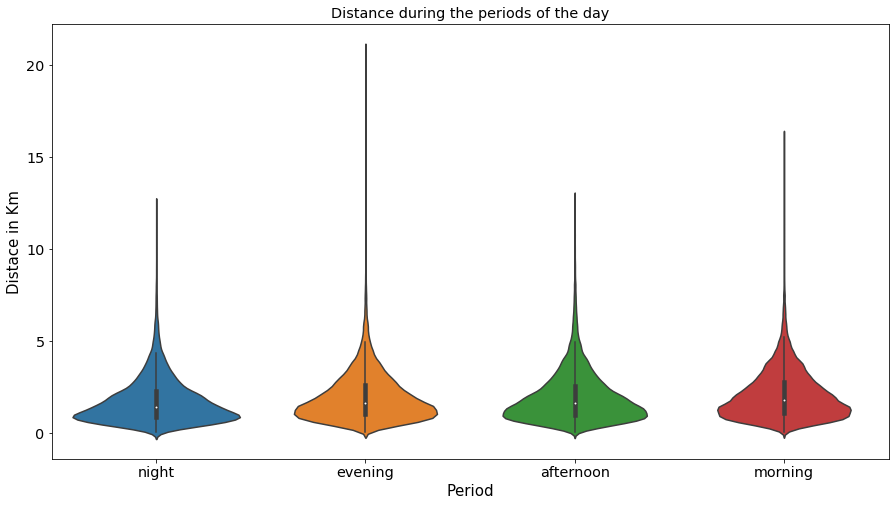

```python
# Violin chart for User Type and Pace

def graph():
    sb.violinplot(data = df_other, x = 'period', y = 'distance_km');
    plt.ylabel('Distace in Km', fontsize=15)
    plt.xlabel('Period', fontsize=15)

plt.figure(figsize=[15,8])
plt.title('Distance during the periods of the day')

graph()
```

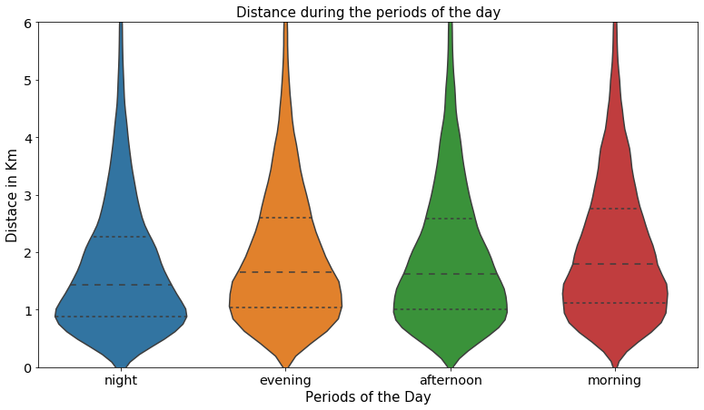

```python
# Violin chart for User Type and Pace

def graph():
    sb.violinplot(data = df_other, x = 'period', y = 'distance_km', inner = 'quartile', fontsize=15);
    plt.ylabel('Distace in Km', fontsize=15)
    plt.xlabel('Periods of the Day', fontsize=15)

plt.figure(figsize=[13,7])
plt.ylim([0, 6])
plt.title('Distance during the periods of the day', fontsize=15)

graph()
```

People tend to use the bike to cover smaller distances during the night. The evening and afternoon periods have similar distance patterns. The morning period has a smoother distribution of distance covered.

## Multivariate Exploration

### User Type X Distance and Time

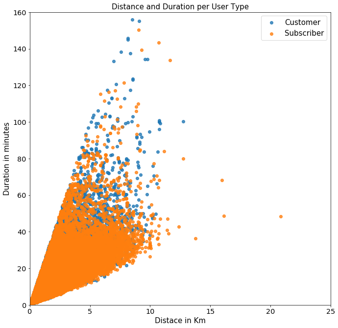

```python
graph_user_type()
```

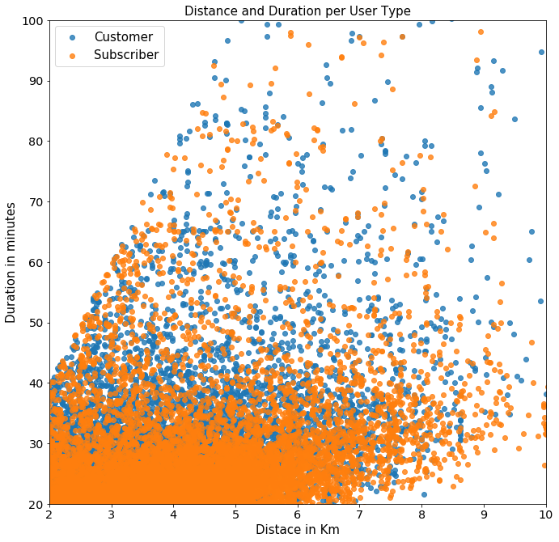

```python
graph_user_type_zoom()
```

The first analysis in Multivariate Exploration is between the categorical variable User Type and the two numeric variables Distance in Km and Duration in Minutes. In the first plot, we can see that customers are the majority after 40 minutes of biking. So in the second graph, we zoomed in to analyze this difference. When zooming in, the difference becomes even more clear. We can see that the differences in duration started before the 40 minutes mark, around the 30 minutes mark.

### Periods X Distance and Time

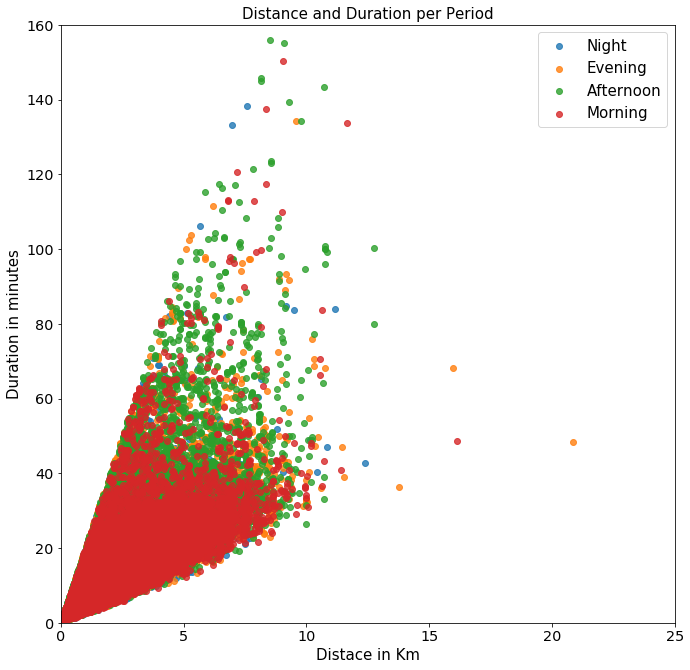

```python
graph_period()
```

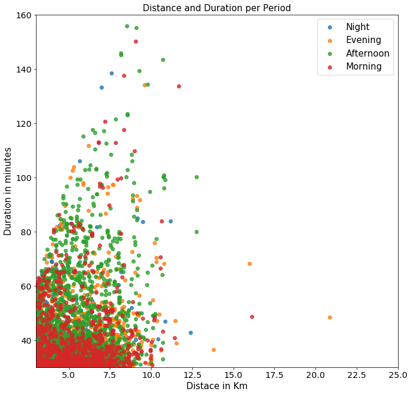

```python
graph_period_zoom()
```

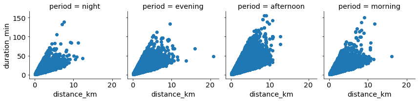

```python
graph_period_facet()
```

The second analysis is between the periods of the day and again, distance and duration. The first graph shows us that the afternoon period is dominant after 40 minutes of biking. Again, we zoom in tho have a closer look. Now it is clear that night is the minority of records and afternoon the majority. Morning rides tend to end before 50 minutes and about 7.5 kilometers of distance. Afternoon rides have more chance of being longer rides in time, distance is almost the same for evening, afternoon and morning.

In the graphs above, we can see the differences between morning and afternoon especially with the duration in distances smaller than 5 km. During the morning people tend to bike faster than during the afternoon, in distances smaller than 5 km. The afternoon duration distribution is smoother.

## Conclusions

```
- Distance and time are correlated and influenced by the periods of the day.
- The user type has a small influence on distance and time.
- The periods of the day have a direct influence on distance and time.
```